# Results: Program 1

The CONTENTS Procedure

| Data Set Name | WORK.IMPORT | Observations | 60627 |
| --- | --- | --- | --- |
| Member Type | DATA | Variables | 47 |
| Engine | V9 | Indexes | 0 |
| Created | 03/19/2025 12:42:32 | Observation Length | 432 |
| Last Modified | 03/19/2025 12:42:32 | Deleted Observations | 0 |
| Protection |  | Compressed | NO |
| Data Set Type |  | Sorted | NO |
| Label |  |  |  |
| Data Representation | SOLARIS_X86_64, LINUX_X86_64, ALPHA_TRU64, LINUX_IA64 |  |  |
| Encoding | utf-8 Unicode (UTF-8) |  |  |

| Engine/Host Dependent Information |  |
| --- | --- |
| Data Set Page Size | 131072 |
| Number of Data Set Pages | 201 |
| First Data Page | 1 |
| Max Obs per Page | 303 |
| Obs in First Data Page | 283 |
| Number of Data Set Repairs | 0 |
| Filename | /saswork/SAS_work76750000571A_odaws01-usw2.oda.sas.com/SAS_workF4EA0000571A_odaws01-usw2.oda.sas.com/import.sas7bdat |
| Release Created | 9.0401M7 |
| Host Created | Linux |
| Inode Number | 1610786755 |
| Access Permission | rw-r--r-- |
| Owner Name | u64189948 |
| File Size | 25MB |
| File Size (bytes) | 26476544 |

| Alphabetic List of Variables and Attributes # | Alphabetic List of Variables and Attributes Variable | Alphabetic List of Variables and Attributes Type | Alphabetic List of Variables and Attributes Len | Alphabetic List of Variables and Attributes Format | Alphabetic List of Variables and Attributes Informat |
| --- | --- | --- | --- | --- | --- |
| 24 | Age Group | Char | 14 | $14. | $14. |
| 5 | Arrival Day | Char | 3 | $3. | $3. |
| 6 | Arrival Hour | Num | 8 | BEST12. | BEST32. |
| 9 | Arrival Shift (1st: 12 AM) | Char | 7 | $7. | $7. |
| 8 | Arrival Shift (1st:11 PM) | Char | 7 | $7. | $7. |
| 7 | Arrival_Hr_Rd | Num | 8 | BEST12. | BEST32. |
| 10 | Bed_Date | Num | 8 | BEST12. | BEST32. |
| 29 | BehavioralHealth | Char | 1 | $1. | $1. |
| 23 | CalcAgeInYears | Num | 8 | BEST12. | BEST32. |
| 30 | DispoType | Char | 20 | $20. | $20. |
| 2 | EDArrivalDate | Num | 8 | BEST12. | BEST32. |
| 25 | EDLevel | Char | 25 | $25. | $25. |
| 16 | EDOUBedDate | Num | 8 | BEST12. | BEST32. |
| 21 | ESILevel | Char | 11 | $11. | $11. |
| 27 | FinalDiagnosis | Char | 44 | $44. | $44. |
| 12 | First provider in hours | Num | 8 | BEST12. | BEST32. |
| 11 | FirstProviderSignUpDate | Num | 8 | BEST12. | BEST32. |
| 44 | FirstWard | Char | 7 | $7. | $7. |
| 22 | Gender | Char | 1 | $1. | $1. |
| 47 | ID | Num | 8 | BEST12. | BEST32. |
| 18 | LOS | Num | 8 | BEST12. | BEST32. |
| 19 | LOS rounded | Num | 8 | BEST12. | BEST32. |
| 20 | LOS_OBS | Num | 8 | BEST12. | BEST32. |
| 45 | LastWard | Char | 4 | $4. | $4. |
| 4 | Month | Char | 3 | $3. | $3. |
| 28 | Pat_OrderCount_Total | Num | 8 | BEST12. | BEST32. |
| 32 | PatientsPerMD_Max | Num | 8 | BEST12. | BEST32. |
| 33 | PatientsPerMD_Mean | Num | 8 | BEST12. | BEST32. |
| 34 | PatientsPerMD_Mean_Rd | Num | 8 | BEST12. | BEST32. |
| 35 | PatientsPerMD_Med | Num | 8 | BEST12. | BEST32. |
| 36 | PatientsPerNURSE_Max | Num | 8 | BEST12. | BEST32. |
| 37 | PatientsPerNURSE_Mean | Num | 8 | BEST12. | BEST32. |
| 38 | PatientsPerNURSE_Mean_Rd | Num | 8 | BEST12. | BEST32. |
| 39 | PatientsPerNURSE_Med | Num | 8 | BEST12. | BEST32. |
| 40 | PatientsPerPA_RESIDENT_Max | Num | 8 | BEST12. | BEST32. |
| 41 | PatientsPerPA_RESIDENT_Mean | Num | 8 | BEST12. | BEST32. |
| 42 | PatientsPerPA_RESIDENT_Mean_Rd | Num | 8 | BEST12. | BEST32. |
| 43 | PatientsPerPA_RESIDENT_Med | Num | 8 | BEST12. | BEST32. |
| 17 | PhysicalDepartDate | Num | 8 | BEST12. | BEST32. |
| 26 | PresentingComplaint | Char | 21 | $21. | $21. |
| 3 | Shift | Num | 8 | BEST12. | BEST32. |
| 31 | TransportArrive | Char | 10 | $10. | $10. |
| 1 | VAR1 | Num | 8 | BEST12. | BEST32. |
| 15 | Waiting for 1st provider_Rd | Num | 8 | BEST12. | BEST32. |
| 14 | Waiting for 1st provider_Rd2 | Num | 8 | BEST12. | BEST32. |
| 13 | Waiting for First provider | Num | 8 | BEST12. | BEST32. |
| 46 | Ward Change | Char | 3 | $3. | $3. |

The CONTENTS Procedure

| Data Set Name | WORK.IMPORT | Observations | 60627 |
| --- | --- | --- | --- |
| Member Type | DATA | Variables | 47 |
| Engine | V9 | Indexes | 0 |
| Created | 03/19/2025 12:42:32 | Observation Length | 432 |
| Last Modified | 03/19/2025 12:42:32 | Deleted Observations | 0 |
| Protection |  | Compressed | NO |
| Data Set Type |  | Sorted | NO |
| Label |  |  |  |
| Data Representation | SOLARIS_X86_64, LINUX_X86_64, ALPHA_TRU64, LINUX_IA64 |  |  |
| Encoding | utf-8 Unicode (UTF-8) |  |  |

| Engine/Host Dependent Information |  |
| --- | --- |
| Data Set Page Size | 131072 |
| Number of Data Set Pages | 201 |
| First Data Page | 1 |
| Max Obs per Page | 303 |
| Obs in First Data Page | 283 |
| Number of Data Set Repairs | 0 |
| Filename | /saswork/SAS_work76750000571A_odaws01-usw2.oda.sas.com/SAS_workF4EA0000571A_odaws01-usw2.oda.sas.com/import.sas7bdat |
| Release Created | 9.0401M7 |
| Host Created | Linux |
| Inode Number | 1610786755 |
| Access Permission | rw-r--r-- |
| Owner Name | u64189948 |
| File Size | 25MB |
| File Size (bytes) | 26476544 |

| Alphabetic List of Variables and Attributes # | Alphabetic List of Variables and Attributes Variable | Alphabetic List of Variables and Attributes Type | Alphabetic List of Variables and Attributes Len | Alphabetic List of Variables and Attributes Format | Alphabetic List of Variables and Attributes Informat |
| --- | --- | --- | --- | --- | --- |
| 24 | Age Group | Char | 14 | $14. | $14. |
| 5 | Arrival Day | Char | 3 | $3. | $3. |
| 6 | Arrival Hour | Num | 8 | BEST12. | BEST32. |
| 9 | Arrival Shift (1st: 12 AM) | Char | 7 | $7. | $7. |
| 8 | Arrival Shift (1st:11 PM) | Char | 7 | $7. | $7. |
| 7 | Arrival_Hr_Rd | Num | 8 | BEST12. | BEST32. |
| 10 | Bed_Date | Num | 8 | BEST12. | BEST32. |
| 29 | BehavioralHealth | Char | 1 | $1. | $1. |
| 23 | CalcAgeInYears | Num | 8 | BEST12. | BEST32. |
| 30 | DispoType | Char | 20 | $20. | $20. |
| 2 | EDArrivalDate | Num | 8 | BEST12. | BEST32. |
| 25 | EDLevel | Char | 25 | $25. | $25. |
| 16 | EDOUBedDate | Num | 8 | BEST12. | BEST32. |
| 21 | ESILevel | Char | 11 | $11. | $11. |
| 27 | FinalDiagnosis | Char | 44 | $44. | $44. |
| 12 | First provider in hours | Num | 8 | BEST12. | BEST32. |
| 11 | FirstProviderSignUpDate | Num | 8 | BEST12. | BEST32. |
| 44 | FirstWard | Char | 7 | $7. | $7. |
| 22 | Gender | Char | 1 | $1. | $1. |
| 47 | ID | Num | 8 | BEST12. | BEST32. |
| 18 | LOS | Num | 8 | BEST12. | BEST32. |
| 19 | LOS rounded | Num | 8 | BEST12. | BEST32. |
| 20 | LOS_OBS | Num | 8 | BEST12. | BEST32. |
| 45 | LastWard | Char | 4 | $4. | $4. |
| 4 | Month | Char | 3 | $3. | $3. |
| 28 | Pat_OrderCount_Total | Num | 8 | BEST12. | BEST32. |
| 32 | PatientsPerMD_Max | Num | 8 | BEST12. | BEST32. |
| 33 | PatientsPerMD_Mean | Num | 8 | BEST12. | BEST32. |
| 34 | PatientsPerMD_Mean_Rd | Num | 8 | BEST12. | BEST32. |
| 35 | PatientsPerMD_Med | Num | 8 | BEST12. | BEST32. |
| 36 | PatientsPerNURSE_Max | Num | 8 | BEST12. | BEST32. |
| 37 | PatientsPerNURSE_Mean | Num | 8 | BEST12. | BEST32. |
| 38 | PatientsPerNURSE_Mean_Rd | Num | 8 | BEST12. | BEST32. |
| 39 | PatientsPerNURSE_Med | Num | 8 | BEST12. | BEST32. |
| 40 | PatientsPerPA_RESIDENT_Max | Num | 8 | BEST12. | BEST32. |
| 41 | PatientsPerPA_RESIDENT_Mean | Num | 8 | BEST12. | BEST32. |
| 42 | PatientsPerPA_RESIDENT_Mean_Rd | Num | 8 | BEST12. | BEST32. |
| 43 | PatientsPerPA_RESIDENT_Med | Num | 8 | BEST12. | BEST32. |
| 17 | PhysicalDepartDate | Num | 8 | BEST12. | BEST32. |
| 26 | PresentingComplaint | Char | 21 | $21. | $21. |
| 3 | Shift | Num | 8 | BEST12. | BEST32. |
| 31 | TransportArrive | Char | 10 | $10. | $10. |
| 1 | VAR1 | Num | 8 | BEST12. | BEST32. |
| 15 | Waiting for 1st provider_Rd | Num | 8 | BEST12. | BEST32. |
| 14 | Waiting for 1st provider_Rd2 | Num | 8 | BEST12. | BEST32. |
| 13 | Waiting for First provider | Num | 8 | BEST12. | BEST32. |
| 46 | Ward Change | Char | 3 | $3. | $3. |

The CONTENTS Procedure

| Data Set Name | WORK.ED_SUBSET | Observations | 60627 |
| --- | --- | --- | --- |
| Member Type | DATA | Variables | 15 |
| Engine | V9 | Indexes | 0 |
| Created | 03/19/2025 15:36:25 | Observation Length | 184 |
| Last Modified | 03/19/2025 15:36:25 | Deleted Observations | 0 |
| Protection |  | Compressed | NO |
| Data Set Type |  | Sorted | NO |
| Label |  |  |  |
| Data Representation | SOLARIS_X86_64, LINUX_X86_64, ALPHA_TRU64, LINUX_IA64 |  |  |
| Encoding | utf-8 Unicode (UTF-8) |  |  |

| Engine/Host Dependent Information |  |
| --- | --- |
| Data Set Page Size | 131072 |
| Number of Data Set Pages | 86 |
| First Data Page | 1 |
| Max Obs per Page | 711 |
| Obs in First Data Page | 690 |
| Number of Data Set Repairs | 0 |
| Filename | /saswork/SAS_work76750000571A_odaws01-usw2.oda.sas.com/SAS_workF4EA0000571A_odaws01-usw2.oda.sas.com/ed_subset.sas7bdat |
| Release Created | 9.0401M7 |
| Host Created | Linux |
| Inode Number | 1610762287 |
| Access Permission | rw-r--r-- |
| Owner Name | u64189948 |
| File Size | 11MB |
| File Size (bytes) | 11403264 |

| Alphabetic List of Variables and Attributes # | Alphabetic List of Variables and Attributes Variable | Alphabetic List of Variables and Attributes Type | Alphabetic List of Variables and Attributes Len | Alphabetic List of Variables and Attributes Format | Alphabetic List of Variables and Attributes Informat |
| --- | --- | --- | --- | --- | --- |
| 6 | Age Group | Char | 14 | $14. | $14. |
| 1 | Arrival Day | Char | 3 | $3. | $3. |
| 2 | Arrival Shift (1st: 12 AM) | Char | 7 | $7. | $7. |
| 9 | DispoType | Char | 20 | $20. | $20. |
| 7 | EDLevel | Char | 25 | $25. | $25. |
| 4 | ESILevel | Char | 11 | $11. | $11. |
| 8 | FinalDiagnosis | Char | 44 | $44. | $44. |
| 14 | FirstWard | Char | 7 | $7. | $7. |
| 5 | Gender | Char | 1 | $1. | $1. |
| 3 | LOS rounded | Num | 8 | BEST12. | BEST32. |
| 11 | PatientsPerMD_Mean_Rd | Num | 8 | BEST12. | BEST32. |
| 12 | PatientsPerNURSE_Mean_Rd | Num | 8 | BEST12. | BEST32. |
| 13 | PatientsPerPA_RESIDENT_Mean_Rd | Num | 8 | BEST12. | BEST32. |
| 10 | TransportArrive | Char | 10 | $10. | $10. |
| 15 | Ward Change | Char | 3 | $3. | $3. |

The UNIVARIATE Procedure

Variable: LOS rounded

| Moments |  |  |  |
| --- | --- | --- | --- |
| N | 60627 | Sum Weights | 60627 |
| Mean | 3.97000841 | Sum Observations | 240689.7 |
| Std Deviation | 2.31530944 | Variance | 5.36065782 |
| Skewness | 4.48625911 | Kurtosis | 89.2768004 |
| Uncorrected SS | 1280535.37 | Corrected SS | 324995.241 |
| Coeff Variation | 58.3200135 | Std Error Mean | 0.00940321 |

| Basic Statistical Measures Location | Basic Statistical Measures Location | Basic Statistical Measures Variability | Basic Statistical Measures Variability |
| --- | --- | --- | --- |
| Mean | 3.970008 | Std Deviation | 2.31531 |
| Median | 3.650000 | Variance | 5.36066 |
| Mode | 2.880000 | Range | 85.97000 |
|  |  | Interquartile Range | 2.73000 |

| Tests for Location: Mu0=0 Test | Tests for Location: Mu0=0 Statistic | Tests for Location: Mu0=0 Statistic | Tests for Location: Mu0=0 p Value | Tests for Location: Mu0=0 p Value |
| --- | --- | --- | --- | --- |
| Student's t | t | 422.1973 | Pr > \|t\| | <.0001 |
| Sign | M | 30313.5 | Pr >= \|M\| | <.0001 |
| Signed Rank | S | 9.1892E8 | Pr >= \|S\| | <.0001 |

| Quantiles (Definition 5) Level | Quantiles (Definition 5) Quantile |
| --- | --- |
| 100% Max | 86.00 |
| 99% | 10.03 |
| 95% | 7.77 |
| 90% | 6.73 |
| 75% Q3 | 5.13 |
| 50% Median | 3.65 |
| 25% Q1 | 2.40 |
| 10% | 1.55 |
| 5% | 1.13 |
| 1% | 0.62 |
| 0% Min | 0.03 |

| Extreme Observations Lowest Value | Extreme Observations Lowest Obs | Extreme Observations Highest Value | Extreme Observations Highest Obs |
| --- | --- | --- | --- |
| 0.03 | 49920 | 57.30 | 36715 |
| 0.04 | 49918 | 57.55 | 46861 |
| 0.07 | 3975 | 70.07 | 51435 |
| 0.07 | 2680 | 74.88 | 45058 |
| 0.10 | 1367 | 86.00 | 3948 |

The UNIVARIATE Procedure

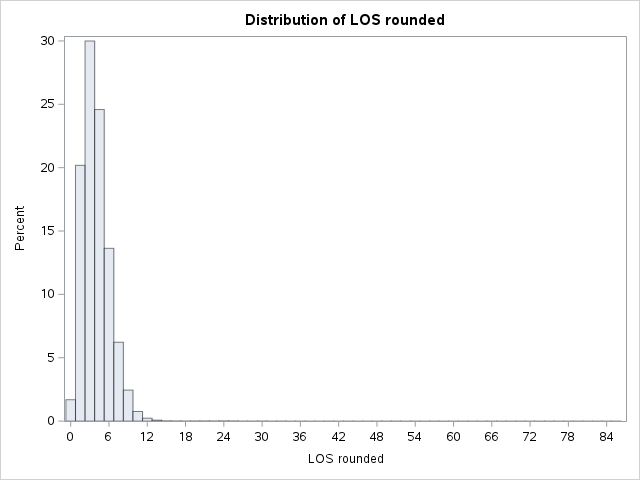

The UNIVARIATE Procedure

Variable: PatientsPerMD_Mean_Rd

| Moments |  |  |  |
| --- | --- | --- | --- |
| N | 60622 | Sum Weights | 60622 |
| Mean | 12.0399141 | Sum Observations | 729883.67 |
| Std Deviation | 3.52644026 | Variance | 12.4357809 |
| Skewness | 3.67540076 | Kurtosis | 35.2112167 |
| Uncorrected SS | 9541606.13 | Corrected SS | 753869.475 |
| Coeff Variation | 29.28958 | Std Error Mean | 0.01432258 |

| Basic Statistical Measures Location | Basic Statistical Measures Location | Basic Statistical Measures Variability | Basic Statistical Measures Variability |
| --- | --- | --- | --- |
| Mean | 12.03991 | Std Deviation | 3.52644 |
| Median | 11.62000 | Variance | 12.43578 |
| Mode | 10.82000 | Range | 64.46000 |
|  |  | Interquartile Range | 3.82000 |

| Tests for Location: Mu0=0 Test | Tests for Location: Mu0=0 Statistic | Tests for Location: Mu0=0 Statistic | Tests for Location: Mu0=0 p Value | Tests for Location: Mu0=0 p Value |
| --- | --- | --- | --- | --- |
| Student's t | t | 840.6244 | Pr > \|t\| | <.0001 |
| Sign | M | 30311 | Pr >= \|M\| | <.0001 |
| Signed Rank | S | 9.1877E8 | Pr >= \|S\| | <.0001 |

| Quantiles (Definition 5) Level | Quantiles (Definition 5) Quantile |
| --- | --- |
| 100% Max | 68.03 |
| 99% | 20.95 |
| 95% | 16.95 |
| 90% | 15.70 |
| 75% Q3 | 13.73 |
| 50% Median | 11.62 |
| 25% Q1 | 9.91 |
| 10% | 8.53 |
| 5% | 7.72 |
| 1% | 6.44 |
| 0% Min | 3.57 |

| Extreme Observations Lowest Value | Extreme Observations Lowest Obs | Extreme Observations Highest Value | Extreme Observations Highest Obs |
| --- | --- | --- | --- |
| 3.57 | 1501 | 62.27 | 35004 |
| 3.59 | 1502 | 62.27 | 35005 |
| 3.75 | 1500 | 62.27 | 35007 |
| 3.78 | 494 | 62.27 | 35010 |
| 3.84 | 24031 | 68.03 | 35009 |

| Missing Values Missing Value | Missing Values Count | Missing Values Percent Of All Obs | Missing Values Percent Of Missing Obs |
| --- | --- | --- | --- |
| . | 5 | 0.01 | 100.00 |

The UNIVARIATE Procedure

Variable: PatientsPerNURSE_Mean_Rd

| Moments |  |  |  |
| --- | --- | --- | --- |
| N | 60622 | Sum Weights | 60622 |
| Mean | 1.55246577 | Sum Observations | 94113.58 |
| Std Deviation | 0.49573685 | Variance | 0.24575502 |
| Skewness | 15.3050416 | Kurtosis | 605.89168 |
| Uncorrected SS | 161006.027 | Corrected SS | 14897.9152 |
| Coeff Variation | 31.932224 | Std Error Mean | 0.00201343 |

| Basic Statistical Measures Location | Basic Statistical Measures Location | Basic Statistical Measures Variability | Basic Statistical Measures Variability |
| --- | --- | --- | --- |
| Mean | 1.552466 | Std Deviation | 0.49574 |
| Median | 1.530000 | Variance | 0.24576 |
| Mode | 1.460000 | Range | 29.34000 |
|  |  | Interquartile Range | 0.47000 |

| Tests for Location: Mu0=0 Test | Tests for Location: Mu0=0 Statistic | Tests for Location: Mu0=0 Statistic | Tests for Location: Mu0=0 p Value | Tests for Location: Mu0=0 p Value |
| --- | --- | --- | --- | --- |
| Student's t | t | 771.0561 | Pr > \|t\| | <.0001 |
| Sign | M | 30311 | Pr >= \|M\| | <.0001 |
| Signed Rank | S | 9.1877E8 | Pr >= \|S\| | <.0001 |

| Quantiles (Definition 5) Level | Quantiles (Definition 5) Quantile |
| --- | --- |
| 100% Max | 29.78 |
| 99% | 2.50 |
| 95% | 2.13 |
| 90% | 1.99 |
| 75% Q3 | 1.77 |
| 50% Median | 1.53 |
| 25% Q1 | 1.30 |
| 10% | 1.10 |
| 5% | 0.98 |
| 1% | 0.78 |
| 0% Min | 0.44 |

| Extreme Observations Lowest Value | Extreme Observations Lowest Obs | Extreme Observations Highest Value | Extreme Observations Highest Obs |
| --- | --- | --- | --- |
| 0.44 | 49550 | 20.90 | 35044 |
| 0.46 | 11763 | 20.90 | 35051 |
| 0.47 | 49549 | 23.97 | 16506 |
| 0.48 | 58203 | 29.27 | 35037 |
| 0.49 | 15688 | 29.78 | 35041 |

| Missing Values Missing Value | Missing Values Count | Missing Values Percent Of All Obs | Missing Values Percent Of Missing Obs |
| --- | --- | --- | --- |
| . | 5 | 0.01 | 100.00 |

The UNIVARIATE Procedure

Variable: PatientsPerPA_RESIDENT_Mean_Rd

| Moments |  |  |  |
| --- | --- | --- | --- |
| N | 60622 | Sum Weights | 60622 |
| Mean | 5.04174772 | Sum Observations | 305640.83 |
| Std Deviation | 2.4235487 | Variance | 5.87358828 |
| Skewness | 8.20668141 | Kurtosis | 104.145119 |
| Uncorrected SS | 1897026.75 | Corrected SS | 356062.795 |
| Coeff Variation | 48.0696146 | Std Error Mean | 0.00984321 |

| Basic Statistical Measures Location | Basic Statistical Measures Location | Basic Statistical Measures Variability | Basic Statistical Measures Variability |
| --- | --- | --- | --- |
| Mean | 5.041748 | Std Deviation | 2.42355 |
| Median | 4.760000 | Variance | 5.87359 |
| Mode | 4.910000 | Range | 48.37000 |
|  |  | Interquartile Range | 1.65000 |

| Tests for Location: Mu0=0 Test | Tests for Location: Mu0=0 Statistic | Tests for Location: Mu0=0 Statistic | Tests for Location: Mu0=0 p Value | Tests for Location: Mu0=0 p Value |
| --- | --- | --- | --- | --- |
| Student's t | t | 512.2058 | Pr > \|t\| | <.0001 |
| Sign | M | 30311 | Pr >= \|M\| | <.0001 |
| Signed Rank | S | 9.1877E8 | Pr >= \|S\| | <.0001 |

| Quantiles (Definition 5) Level | Quantiles (Definition 5) Quantile |
| --- | --- |
| 100% Max | 49.45 |
| 99% | 12.42 |
| 95% | 7.31 |
| 90% | 6.52 |
| 75% Q3 | 5.63 |
| 50% Median | 4.76 |
| 25% Q1 | 3.98 |
| 10% | 3.32 |
| 5% | 2.96 |
| 1% | 2.42 |
| 0% Min | 1.08 |

| Extreme Observations Lowest Value | Extreme Observations Lowest Obs | Extreme Observations Highest Value | Extreme Observations Highest Obs |
| --- | --- | --- | --- |
| 1.08 | 1482 | 48.88 | 26191 |
| 1.21 | 1483 | 48.88 | 26196 |
| 1.24 | 1480 | 48.88 | 26198 |
| 1.26 | 1481 | 49.45 | 26195 |
| 1.32 | 1479 | 49.45 | 26206 |

| Missing Values Missing Value | Missing Values Count | Missing Values Percent Of All Obs | Missing Values Percent Of Missing Obs |
| --- | --- | --- | --- |
| . | 5 | 0.01 | 100.00 |

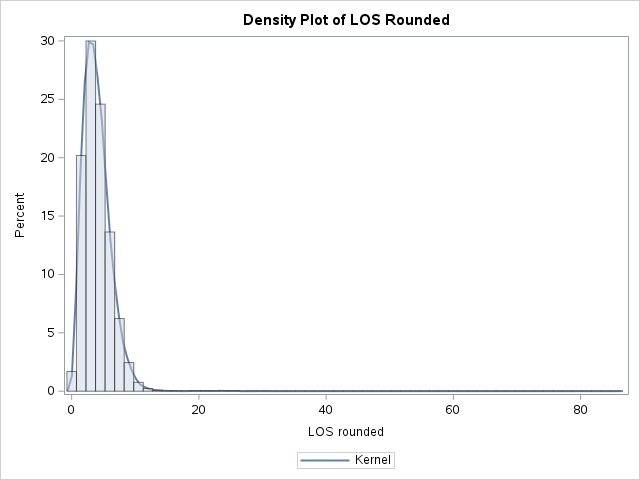

Final Diagnosis Distribution for LOS Rounded > 24

The FREQ Procedure

| FinalDiagnosis | Frequency | Cumulative Frequency |
| --- | --- | --- |
| Abdominal Pain | 1 | 1 |
| Acute right eye vision loss | 1 | 2 |
| Auditory hallucinations | 2 | 4 |
| Depression | 8 | 12 |
| Foreign body - cornea | 1 | 13 |
| Insomnia | 1 | 14 |
| Psychosis | 2 | 16 |
| SI | 1 | 17 |
| Severe depression | 1 | 18 |
| Suicidal ideation | 19 | 37 |
| Suicidal ideation with recent attempt of han | 1 | 38 |
| acute L chest cellulitis | 1 | 39 |
| behavioral dyscontrol | 1 | 40 |
| dizziness | 1 | 41 |
| hallucinations | 1 | 42 |
| schizophrenia | 1 | 43 |
| urinary retention | 1 | 44 |

Frequency Distribution of FirstWard (Excluding NA)

The FREQ Procedure

| FirstWard | Frequency | Percent | Cumulative Frequency | Cumulative Percent |
| --- | --- | --- | --- | --- |
| CENTER1 | 16013 | 26.66 | 16013 | 26.66 |
| CENTER2 | 14087 | 23.45 | 30100 | 50.11 |
| EAST | 6431 | 10.71 | 36531 | 60.81 |
| PEDS | 8654 | 14.41 | 45185 | 75.22 |
| WEST | 14885 | 24.78 | 60070 | 100.00 |

The FREQ Procedure

| FinalDiagnosis | Frequency | Cumulative Frequency |
| --- | --- | --- |
| Abdominal Pain | 1 | 1 |
| Acute right eye vision loss | 1 | 2 |
| Foreign body - cornea | 1 | 3 |
| Insomnia | 1 | 4 |
| SI | 1 | 5 |
| acute L chest cellulitis | 1 | 6 |
| dizziness | 1 | 7 |
| urinary retention | 1 | 8 |

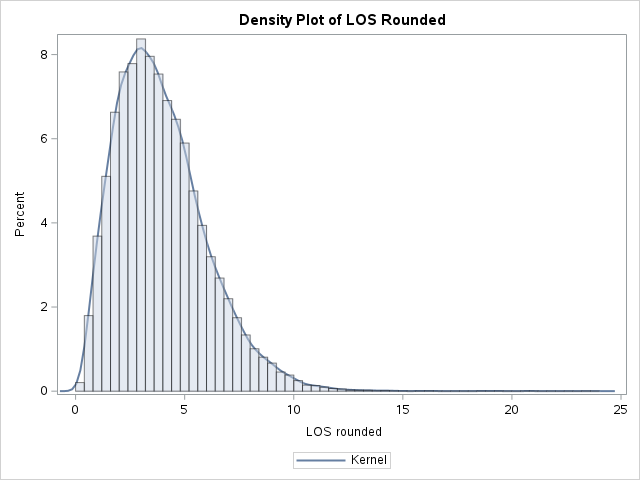

Correlation Analysis of PatientsPerMD_Mean_Rd, PatientsPerNURSE_Mean_Rd, and PatientsPerPA_RESIDENT_Mean_Rd

The CORR Procedure

| 3 Variables: | PatientsPerMD_Mean_Rd PatientsPerNURSE_Mean_Rd PatientsPerPA_RESIDENT_Mean_Rd |
| --- | --- |

| Simple Statistics Variable | Simple Statistics N | Simple Statistics Mean | Simple Statistics Std Dev | Simple Statistics Sum | Simple Statistics Minimum | Simple Statistics Maximum |
| --- | --- | --- | --- | --- | --- | --- |
| PatientsPerMD_Mean_Rd | 59803 | 12.03562 | 3.52653 | 719766 | 3.57000 | 68.03000 |
| PatientsPerNURSE_Mean_Rd | 59803 | 1.55169 | 0.49741 | 92796 | 0.44000 | 29.78000 |
| PatientsPerPA_RESIDENT_Mean_Rd | 59803 | 5.04070 | 2.42257 | 301449 | 1.08000 | 49.45000 |

| Pearson Correlation Coefficients, N = 59803 Prob > \|r\| under H0: Rho=0 | Pearson Correlation Coefficients, N = 59803 Prob > \|r\| under H0: Rho=0 PatientsPerMD_Mean_Rd | Pearson Correlation Coefficients, N = 59803 Prob > \|r\| under H0: Rho=0 PatientsPerNURSE_Mean_Rd | Pearson Correlation Coefficients, N = 59803 Prob > \|r\| under H0: Rho=0 PatientsPerPA_RESIDENT_Mean_Rd |
| --- | --- | --- | --- |
| PatientsPerMD_Mean_Rd | 1.00000 | 0.57843 <.0001 | 0.55143 <.0001 |
| PatientsPerNURSE_Mean_Rd | 0.57843 <.0001 | 1.00000 | 0.45792 <.0001 |
| PatientsPerPA_RESIDENT_Mean_Rd | 0.55143 <.0001 | 0.45792 <.0001 | 1.00000 |

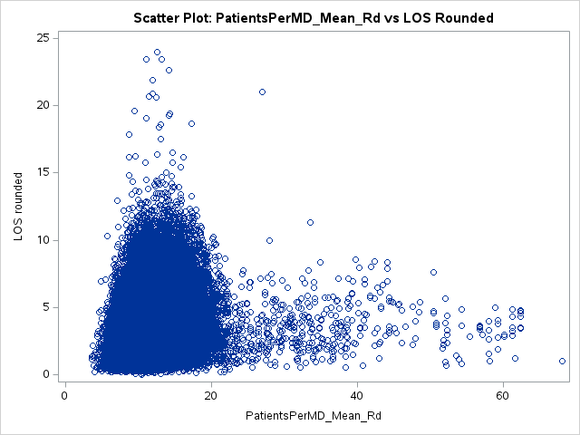

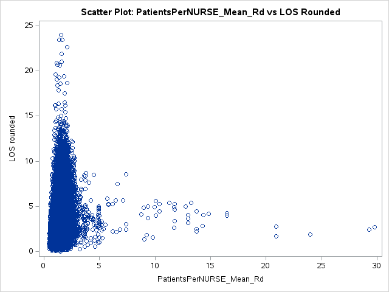

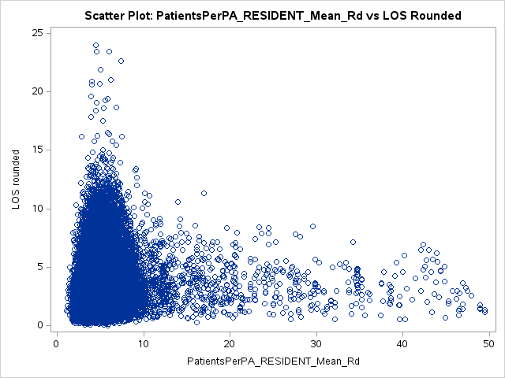

Frequency Distribution of Arrival Day

The FREQ Procedure

| Arrival Day | Frequency | Percent | Cumulative Frequency | Cumulative Percent |
| --- | --- | --- | --- | --- |
| Fri | 8418 | 14.08 | 8418 | 14.08 |
| Mon | 9184 | 15.36 | 17602 | 29.43 |
| Sat | 8393 | 14.03 | 25995 | 43.46 |
| Sun | 8591 | 14.36 | 34586 | 57.83 |
| Thu | 8277 | 13.84 | 42863 | 71.67 |
| Tue | 8500 | 14.21 | 51363 | 85.88 |
| Wed | 8445 | 14.12 | 59808 | 100.00 |

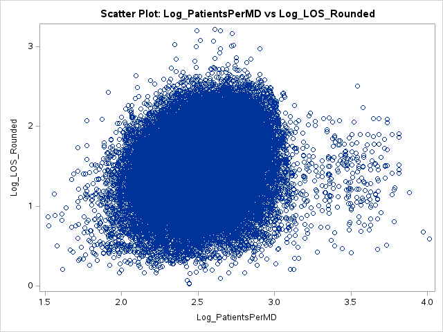

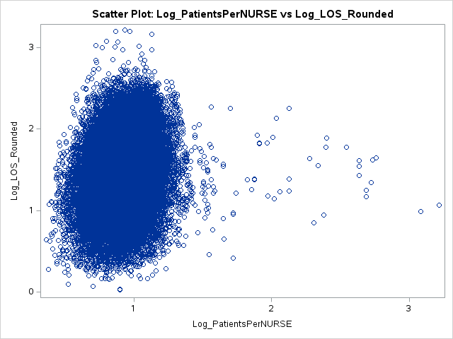

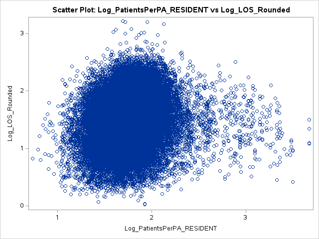

The CONTENTS Procedure

| Data Set Name | WORK.ED_TRANSFORMED | Observations | 42824 |
| --- | --- | --- | --- |
| Member Type | DATA | Variables | 19 |
| Engine | V9 | Indexes | 0 |
| Created | 03/19/2025 15:36:33 | Observation Length | 216 |
| Last Modified | 03/19/2025 15:36:33 | Deleted Observations | 0 |
| Protection |  | Compressed | NO |
| Data Set Type |  | Sorted | NO |
| Label |  |  |  |
| Data Representation | SOLARIS_X86_64, LINUX_X86_64, ALPHA_TRU64, LINUX_IA64 |  |  |
| Encoding | utf-8 Unicode (UTF-8) |  |  |

| Engine/Host Dependent Information |  |
| --- | --- |
| Data Set Page Size | 131072 |
| Number of Data Set Pages | 71 |
| First Data Page | 1 |
| Max Obs per Page | 606 |
| Obs in First Data Page | 585 |
| Number of Data Set Repairs | 0 |
| Filename | /saswork/SAS_work76750000571A_odaws01-usw2.oda.sas.com/SAS_workF4EA0000571A_odaws01-usw2.oda.sas.com/ed_transformed.sas7bdat |
| Release Created | 9.0401M7 |
| Host Created | Linux |
| Inode Number | 1610762299 |
| Access Permission | rw-r--r-- |
| Owner Name | u64189948 |
| File Size | 9MB |
| File Size (bytes) | 9437184 |

| Alphabetic List of Variables and Attributes # | Alphabetic List of Variables and Attributes Variable | Alphabetic List of Variables and Attributes Type | Alphabetic List of Variables and Attributes Len | Alphabetic List of Variables and Attributes Format | Alphabetic List of Variables and Attributes Informat |
| --- | --- | --- | --- | --- | --- |
| 6 | Age Group | Char | 14 | $14. | $14. |
| 1 | Arrival Day | Char | 3 | $3. | $3. |
| 2 | Arrival Shift (1st: 12 AM) | Char | 7 | $7. | $7. |
| 9 | DispoType | Char | 20 | $20. | $20. |
| 7 | EDLevel | Char | 25 | $25. | $25. |
| 4 | ESILevel | Char | 11 | $11. | $11. |
| 8 | FinalDiagnosis | Char | 44 | $44. | $44. |
| 14 | FirstWard | Char | 7 | $7. | $7. |
| 5 | Gender | Char | 1 | $1. | $1. |
| 3 | LOS rounded | Num | 8 | BEST12. | BEST32. |
| 16 | Log_LOS_Rounded | Num | 8 |  |  |
| 17 | Log_PatientsPerMD | Num | 8 |  |  |
| 18 | Log_PatientsPerNURSE | Num | 8 |  |  |
| 19 | Log_PatientsPerPA_RESIDENT | Num | 8 |  |  |
| 11 | PatientsPerMD_Mean_Rd | Num | 8 | BEST12. | BEST32. |
| 12 | PatientsPerNURSE_Mean_Rd | Num | 8 | BEST12. | BEST32. |
| 13 | PatientsPerPA_RESIDENT_Mean_Rd | Num | 8 | BEST12. | BEST32. |
| 10 | TransportArrive | Char | 10 | $10. | $10. |
| 15 | Ward Change | Char | 3 | $3. | $3. |

Regression Analysis of Log_LOS_Rounded with Categorical Variables

The GLM Procedure

| Class Level Information Class | Class Level Information Levels | Class Level Information Values |
| --- | --- | --- |
| Age Group | 3 | 21< Age<65 65 or older Lower or EQ 21 |
| Gender | 2 | F M |
| ESILevel | 6 | Direct Admi ESI Level 1 ESI Level 2 ESI Level 3 ESI Level 4 ESI Level 5 |
| Arrival Shift (1st: 12 AM) | 3 | Shift 1 Shift 2 Shift 3 |
| Arrival Day | 5 | Fri Mon Thu Tue Wed |
| DispoType | 3 | Discharge Hospital Observation Inpatient Admission |
| FirstWard | 6 | CENTER1 CENTER2 EAST NA PEDS WEST |
| Ward Change | 2 | NO YES |
| EDLevel | 6 | EMER DEPT - CRITICAL CARE EMERG DEPT - LEVEL 1 EMERG DEPT - LEVEL 2 EMERG DEPT - LEVEL 3 EMERG DEPT - LEVEL 4 EMERG DEPT - LEVEL 5 |
| TransportArrive | 3 | Ambulance Walk in Wheelchair |

| Number of Observations Read | 42824 |
| --- | --- |
| Number of Observations Used | 42821 |

Regression Analysis of Log_LOS_Rounded with Categorical Variables

The GLM Procedure

Dependent Variable: Log_LOS_Rounded

| Source | DF | Sum of Squares | Mean Square | F Value | Pr > F |
| --- | --- | --- | --- | --- | --- |
| Model | 32 | 2872.340639 | 89.760645 | 791.13 | <.0001 |
| Error | 42788 | 4854.684774 | 0.113459 |  |  |
| Corrected Total | 42820 | 7727.025413 |  |  |  |

| R-Square | Coeff Var | Root MSE | Log_LOS_Rounded Mean |
| --- | --- | --- | --- |
| 0.371727 | 22.01010 | 0.336837 | 1.530374 |

| Source | DF | Type I SS | Mean Square | F Value | Pr > F |
| --- | --- | --- | --- | --- | --- |
| Age Group | 2 | 682.2903902 | 341.1451951 | 3006.77 | <.0001 |
| Gender | 1 | 27.1206550 | 27.1206550 | 239.03 | <.0001 |
| ESILevel | 5 | 377.4933406 | 75.4986681 | 665.43 | <.0001 |
| Log_PatientsPerMD | 1 | 404.7196792 | 404.7196792 | 3567.10 | <.0001 |
| Log_PatientsPerNURSE | 1 | 94.7015727 | 94.7015727 | 834.68 | <.0001 |
| Log_PatientsPerPA_RE | 1 | 2.7562859 | 2.7562859 | 24.29 | <.0001 |
| Arrival Shift (1st: | 2 | 70.2517239 | 35.1258619 | 309.59 | <.0001 |
| Arrival Day | 4 | 0.7777981 | 0.1944495 | 1.71 | 0.1438 |
| DispoType | 2 | 236.0255382 | 118.0127691 | 1040.14 | <.0001 |
| FirstWard | 5 | 192.9112049 | 38.5822410 | 340.05 | <.0001 |
| Ward Change | 1 | 39.3949243 | 39.3949243 | 347.22 | <.0001 |
| EDLevel | 5 | 610.7725585 | 122.1545117 | 1076.64 | <.0001 |
| TransportArrive | 2 | 133.1249677 | 66.5624839 | 586.67 | <.0001 |

| Source | DF | Type III SS | Mean Square | F Value | Pr > F |
| --- | --- | --- | --- | --- | --- |
| Age Group | 2 | 31.0924609 | 15.5462304 | 137.02 | <.0001 |
| Gender | 1 | 9.1107642 | 9.1107642 | 80.30 | <.0001 |
| ESILevel | 5 | 104.5056702 | 20.9011340 | 184.22 | <.0001 |
| Log_PatientsPerMD | 1 | 62.7736854 | 62.7736854 | 553.27 | <.0001 |
| Log_PatientsPerNURSE | 1 | 37.8894674 | 37.8894674 | 333.95 | <.0001 |
| Log_PatientsPerPA_RE | 1 | 3.4300876 | 3.4300876 | 30.23 | <.0001 |
| Arrival Shift (1st: | 2 | 53.5777811 | 26.7888906 | 236.11 | <.0001 |
| Arrival Day | 4 | 0.8108248 | 0.2027062 | 1.79 | 0.1284 |
| DispoType | 2 | 17.3966018 | 8.6983009 | 76.66 | <.0001 |
| FirstWard | 5 | 104.2540895 | 20.8508179 | 183.77 | <.0001 |
| Ward Change | 1 | 29.0476442 | 29.0476442 | 256.02 | <.0001 |
| EDLevel | 5 | 678.0268443 | 135.6053689 | 1195.19 | <.0001 |
| TransportArrive | 2 | 133.1249677 | 66.5624839 | 586.67 | <.0001 |

First 10 Observations of ED_Final3_Cat with LOS Categorized

| Obs | Arrival Day | Arrival Shift (1st: 12 AM) | LOS rounded | ESILevel | Gender | Age Group | EDLevel | FinalDiagnosis | DispoType | TransportArrive | PatientsPerMD_Mean_Rd | PatientsPerNURSE_Mean_Rd | PatientsPerPA_RESIDENT_Mean_Rd | FirstWard | Ward Change | LOS_Cat |
| --- | --- | --- | --- | --- | --- | --- | --- | --- | --- | --- | --- | --- | --- | --- | --- | --- |
| 1 | Mon | Shift 1 | 1.38 | ESI Level 3 | M | 65 or older | EMERG DEPT - LEVEL 3 | LEFT leg pain | Discharge | Walk in | 9.64 | 1.13 | 3.23 | WEST | NO | 0 |
| 2 | Mon | Shift 1 | 2.5 | ESI Level 3 | F | 21< Age<65 | EMERG DEPT - LEVEL 5 | TGA | Discharge | Walk in | 9.26 | 1 | 3.21 | CENTER2 | NO | 0 |
| 3 | Mon | Shift 1 | 1.9 | ESI Level 3 | F | 21< Age<65 | EMERG DEPT - LEVEL 5 | GI bleed | Hospital Observation | Ambulance | 9.56 | 1.04 | 3.07 | CENTER1 | NO | 0 |
| 4 | Mon | Shift 1 | 2.68 | ESI Level 3 | M | 21< Age<65 | EMERG DEPT - LEVEL 4 | Headache | Discharge | Walk in | 9.83 | 0.89 | 3.48 | CENTER1 | NO | 0 |
| 5 | Mon | Shift 1 | 3.43 | ESI Level 3 | F | 21< Age<65 | EMERG DEPT - LEVEL 5 | Abdominal Pain | Discharge | Walk in | 10.9 | 0.86 | 3.79 | CENTER1 | NO | 0 |
| 6 | Mon | Shift 1 | 0.87 | ESI Level 3 | F | 21< Age<65 | EMERG DEPT - LEVEL 4 | Asthma exacerbation | Discharge | Walk in | 10.28 | 0.99 | 3 | CENTER2 | NO | 0 |
| 7 | Mon | Shift 1 | 1.13 | ESI Level 3 | F | 21< Age<65 | EMERG DEPT - LEVEL 4 | assault | Discharge | Walk in | 7.88 | 0.83 | 3.65 | CENTER1 | NO | 0 |
| 8 | Mon | Shift 1 | 0.77 | ESI Level 3 | M | 21< Age<65 | EMERG DEPT - LEVEL 2 | generalized exfoliative dermatitis | Discharge | Walk in | 10.19 | 0.77 | 4 | CENTER2 | NO | 0 |
| 9 | Mon | Shift 1 | 6.63 | ESI Level 3 | F | 21< Age<65 | EMERG DEPT - LEVEL 4 | Headache | Discharge | Walk in | 10.98 | 1.27 | 4.58 | CENTER1 | NO | 1 |
| 10 | Mon | Shift 1 | 2.53 | ESI Level 2 | M | 21< Age<65 | EMER DEPT - CRITICAL CARE | overdose | Inpatient Admission | Ambulance | 11.81 | 0.81 | 3.94 | CENTER2 | NO | 0 |

First 10 Observations of Training Dataset

| Obs | Arrival Day | Arrival Shift (1st: 12 AM) | LOS rounded | ESILevel | Gender | Age Group | EDLevel | FinalDiagnosis | DispoType | TransportArrive | PatientsPerMD_Mean_Rd | PatientsPerNURSE_Mean_Rd | PatientsPerPA_RESIDENT_Mean_Rd | FirstWard | Ward Change | LOS_Cat |
| --- | --- | --- | --- | --- | --- | --- | --- | --- | --- | --- | --- | --- | --- | --- | --- | --- |
| 1 | Mon | Shift 1 | 1.38 | ESI Level 3 | M | 65 or older | EMERG DEPT - LEVEL 3 | LEFT leg pain | Discharge | Walk in | 9.64 | 1.13 | 3.23 | WEST | NO | 0 |
| 2 | Mon | Shift 1 | 2.5 | ESI Level 3 | F | 21< Age<65 | EMERG DEPT - LEVEL 5 | TGA | Discharge | Walk in | 9.26 | 1 | 3.21 | CENTER2 | NO | 0 |
| 3 | Mon | Shift 1 | 1.9 | ESI Level 3 | F | 21< Age<65 | EMERG DEPT - LEVEL 5 | GI bleed | Hospital Observation | Ambulance | 9.56 | 1.04 | 3.07 | CENTER1 | NO | 0 |
| 4 | Mon | Shift 1 | 2.68 | ESI Level 3 | M | 21< Age<65 | EMERG DEPT - LEVEL 4 | Headache | Discharge | Walk in | 9.83 | 0.89 | 3.48 | CENTER1 | NO | 0 |
| 5 | Mon | Shift 1 | 3.43 | ESI Level 3 | F | 21< Age<65 | EMERG DEPT - LEVEL 5 | Abdominal Pain | Discharge | Walk in | 10.9 | 0.86 | 3.79 | CENTER1 | NO | 0 |
| 6 | Mon | Shift 1 | 0.87 | ESI Level 3 | F | 21< Age<65 | EMERG DEPT - LEVEL 4 | Asthma exacerbation | Discharge | Walk in | 10.28 | 0.99 | 3 | CENTER2 | NO | 0 |
| 7 | Mon | Shift 1 | 1.13 | ESI Level 3 | F | 21< Age<65 | EMERG DEPT - LEVEL 4 | assault | Discharge | Walk in | 7.88 | 0.83 | 3.65 | CENTER1 | NO | 0 |
| 8 | Mon | Shift 1 | 0.77 | ESI Level 3 | M | 21< Age<65 | EMERG DEPT - LEVEL 2 | generalized exfoliative dermatitis | Discharge | Walk in | 10.19 | 0.77 | 4 | CENTER2 | NO | 0 |
| 9 | Mon | Shift 1 | 6.63 | ESI Level 3 | F | 21< Age<65 | EMERG DEPT - LEVEL 4 | Headache | Discharge | Walk in | 10.98 | 1.27 | 4.58 | CENTER1 | NO | 1 |
| 10 | Mon | Shift 1 | 2.53 | ESI Level 2 | M | 21< Age<65 | EMER DEPT - CRITICAL CARE | overdose | Inpatient Admission | Ambulance | 11.81 | 0.81 | 3.94 | CENTER2 | NO | 0 |

First 10 Observations of Testing Dataset

| Obs | Arrival Day | Arrival Shift (1st: 12 AM) | LOS rounded | ESILevel | Gender | Age Group | EDLevel | FinalDiagnosis | DispoType | TransportArrive | PatientsPerMD_Mean_Rd | PatientsPerNURSE_Mean_Rd | PatientsPerPA_RESIDENT_Mean_Rd | FirstWard | Ward Change | LOS_Cat |
| --- | --- | --- | --- | --- | --- | --- | --- | --- | --- | --- | --- | --- | --- | --- | --- | --- |
| 1 | Tue | Shift 3 | 1.1 | ESI Level 3 | F | Lower or EQ 21 | EMERG DEPT - LEVEL 3 | Fever | Discharge | Walk in | 14.16 | 1.47 | 4.94 | PEDS | NO | 0 |
| 2 | Tue | Shift 3 | 2.68 | ESI Level 3 | F | 65 or older | EMERG DEPT - LEVEL 4 | Hyponatremia | Discharge | Ambulance | 12.73 | 1.39 | 4.5 | CENTER2 | NO | 0 |
| 3 | Tue | Shift 3 | 3.43 | ESI Level 3 | M | 65 or older | EMERG DEPT - LEVEL 4 | Abdominal Pain | Discharge | Walk in | 12.54 | 1.37 | 4.37 | CENTER1 | NO | 0 |
| 4 | Tue | Shift 3 | 4.82 | ESI Level 3 | F | 21< Age<65 | EMERG DEPT - LEVEL 5 | symptomatic palpations | Discharge | Walk in | 11.72 | 1.17 | 4.27 | WEST | NO | 1 |
| 5 | Tue | Shift 3 | 5.63 | ESI Level 3 | M | 65 or older | EMERG DEPT - LEVEL 5 | chronic severe dehydration | Inpatient Admission | Wheelchair | 10.95 | 1.08 | 4.13 | WEST | NO | 1 |
| 6 | Tue | Shift 3 | 1.97 | ESI Level 3 | M | Lower or EQ 21 | EMERG DEPT - LEVEL 4 | Asthma exacerbation | Discharge | Walk in | 12.07 | 1.34 | 4.16 | PEDS | NO | 0 |
| 7 | Tue | Shift 3 | 2.13 | ESI Level 3 | F | Lower or EQ 21 | EMERG DEPT - LEVEL 3 | LEFT knee pain | Discharge | Wheelchair | 12.07 | 1.34 | 4.16 | PEDS | NO | 0 |
| 8 | Tue | Shift 3 | 3.78 | ESI Level 2 | F | 21< Age<65 | EMERG DEPT - LEVEL 5 | Non STEMI | Inpatient Admission | Ambulance | 11.85 | 1.19 | 4.19 | WEST | NO | 0 |
| 9 | Tue | Shift 3 | 5.32 | ESI Level 3 | F | 65 or older | EMERG DEPT - LEVEL 5 | urinary tract infection | Hospital Observation | Ambulance | 11.15 | 1.09 | 4.15 | CENTER1 | NO | 1 |
| 10 | Tue | Shift 3 | 1.73 | ESI Level 4 | F | 21< Age<65 | EMERG DEPT - LEVEL 3 | tendonitis | Discharge | Wheelchair | 11.97 | 1.36 | 4.16 | CENTER1 | NO | 0 |

Logistic Regression on Training Data

The LOGISTIC Procedure

| Model Information |  |
| --- | --- |
| Data Set | WORK.TRAIN |
| Response Variable | LOS_Cat |
| Number of Response Levels | 2 |
| Model | binary logit |
| Optimization Technique | Fisher's scoring |

| Number of Observations Read | 29976 |
| --- | --- |
| Number of Observations Used | 29973 |

| Response Profile Ordered Value | Response Profile LOS_Cat | Response Profile Total Frequency |
| --- | --- | --- |
| 1 | 1 | 13388 |
| 2 | 0 | 16585 |

Probability modeled is LOS_Cat=1.

Note:3 observations were deleted due to missing values for the response or explanatory variables.

| Class Level Information Class | Class Level Information Value | Class Level Information Design Variables | Class Level Information Design Variables | Class Level Information Design Variables | Class Level Information Design Variables | Class Level Information Design Variables |
| --- | --- | --- | --- | --- | --- | --- |
| Age Group | 21< Age<65 | 1 | 0 |  |  |  |
|  | 65 or older | 0 | 1 |  |  |  |
|  | Lower or EQ 21 | 0 | 0 |  |  |  |
| Gender | F | 1 |  |  |  |  |
|  | M | 0 |  |  |  |  |
| ESILevel | Direct Admi | 1 | 0 | 0 | 0 | 0 |
|  | ESI Level 1 | 0 | 1 | 0 | 0 | 0 |
|  | ESI Level 2 | 0 | 0 | 1 | 0 | 0 |
|  | ESI Level 3 | 0 | 0 | 0 | 1 | 0 |
|  | ESI Level 4 | 0 | 0 | 0 | 0 | 1 |
|  | ESI Level 5 | 0 | 0 | 0 | 0 | 0 |
| Arrival Shift (1st: 12 AM) | Shift 1 | 1 | 0 |  |  |  |
|  | Shift 2 | 0 | 1 |  |  |  |
|  | Shift 3 | 0 | 0 |  |  |  |
| Arrival Day | Fri | 1 | 0 | 0 | 0 |  |
|  | Mon | 0 | 1 | 0 | 0 |  |
|  | Thu | 0 | 0 | 1 | 0 |  |
|  | Tue | 0 | 0 | 0 | 1 |  |
|  | Wed | 0 | 0 | 0 | 0 |  |
| DispoType | Discharge | 1 | 0 |  |  |  |
|  | Hospital Observation | 0 | 1 |  |  |  |
|  | Inpatient Admission | 0 | 0 |  |  |  |
| FirstWard | CENTER1 | 1 | 0 | 0 | 0 | 0 |
|  | CENTER2 | 0 | 1 | 0 | 0 | 0 |
|  | EAST | 0 | 0 | 1 | 0 | 0 |
|  | NA | 0 | 0 | 0 | 1 | 0 |
|  | PEDS | 0 | 0 | 0 | 0 | 1 |
|  | WEST | 0 | 0 | 0 | 0 | 0 |
| Ward Change | NO | 1 |  |  |  |  |
|  | YES | 0 |  |  |  |  |
| EDLevel | EMER DEPT - CRITICAL CARE | 1 | 0 | 0 | 0 | 0 |
|  | EMERG DEPT - LEVEL 1 | 0 | 1 | 0 | 0 | 0 |
|  | EMERG DEPT - LEVEL 2 | 0 | 0 | 1 | 0 | 0 |
|  | EMERG DEPT - LEVEL 3 | 0 | 0 | 0 | 1 | 0 |
|  | EMERG DEPT - LEVEL 4 | 0 | 0 | 0 | 0 | 1 |
|  | EMERG DEPT - LEVEL 5 | 0 | 0 | 0 | 0 | 0 |
| TransportArrive | Ambulance | 1 | 0 |  |  |  |
|  | Walk in | 0 | 1 |  |  |  |
|  | Wheelchair | 0 | 0 |  |  |  |

| Model Convergence Status |
| --- |
| Convergence criterion (GCONV=1E-8) satisfied. |

| Model Fit Statistics Criterion | Model Fit Statistics Intercept Only | Model Fit Statistics Intercept and Covariates |
| --- | --- | --- |
| AIC | 41211.751 | 34021.693 |
| SC | 41220.059 | 34295.859 |
| -2 Log L | 41209.751 | 33955.693 |

| Testing Global Null Hypothesis: BETA=0 Test | Testing Global Null Hypothesis: BETA=0 Chi-Square | Testing Global Null Hypothesis: BETA=0 DF | Testing Global Null Hypothesis: BETA=0 Pr > ChiSq |
| --- | --- | --- | --- |
| Likelihood Ratio | 7254.0579 | 32 | <.0001 |
| Score | 6381.4946 | 32 | <.0001 |
| Wald | 5119.1835 | 32 | <.0001 |

| Type 3 Analysis of Effects Effect | Type 3 Analysis of Effects DF | Type 3 Analysis of Effects Wald Chi-Square | Type 3 Analysis of Effects Pr > ChiSq |
| --- | --- | --- | --- |
| Age Group | 2 | 89.7872 | <.0001 |
| Gender | 1 | 30.6036 | <.0001 |
| ESILevel | 5 | 416.1548 | <.0001 |
| PatientsPerMD_Mean_R | 1 | 176.8587 | <.0001 |
| PatientsPerNURSE_Mea | 1 | 170.3691 | <.0001 |
| PatientsPerPA_RESIDE | 1 | 99.0626 | <.0001 |
| Arrival Shift (1st: | 2 | 158.0528 | <.0001 |
| Arrival Day | 4 | 19.0681 | 0.0008 |
| DispoType | 2 | 82.3697 | <.0001 |
| FirstWard | 5 | 183.4377 | <.0001 |
| Ward Change | 1 | 79.6986 | <.0001 |
| EDLevel | 5 | 1694.0909 | <.0001 |
| TransportArrive | 2 | 445.5800 | <.0001 |

| Analysis of Maximum Likelihood Estimates Parameter | Analysis of Maximum Likelihood Estimates | Analysis of Maximum Likelihood Estimates DF | Analysis of Maximum Likelihood Estimates Estimate | Analysis of Maximum Likelihood Estimates Standard Error | Analysis of Maximum Likelihood Estimates Wald Chi-Square | Analysis of Maximum Likelihood Estimates Pr > ChiSq | Analysis of Maximum Likelihood Estimates Exp(Est) |
| --- | --- | --- | --- | --- | --- | --- | --- |
| Intercept |  | 1 | -0.2228 | 0.2737 | 0.6627 | 0.4156 | 0.800 |
| Age Group | 21< Age<65 | 1 | 0.5542 | 0.0658 | 70.9783 | <.0001 | 1.741 |
| Age Group | 65 or older | 1 | 0.6528 | 0.0689 | 89.7695 | <.0001 | 1.921 |
| Gender | F | 1 | 0.1469 | 0.0266 | 30.6036 | <.0001 | 1.158 |
| ESILevel | Direct Admi | 1 | -0.6485 | 1.2390 | 0.2740 | 0.6007 | 0.523 |
| ESILevel | ESI Level 1 | 1 | -1.4277 | 0.2762 | 26.7217 | <.0001 | 0.240 |
| ESILevel | ESI Level 2 | 1 | -0.8621 | 0.2237 | 14.8570 | 0.0001 | 0.422 |
| ESILevel | ESI Level 3 | 1 | -0.1602 | 0.2212 | 0.5246 | 0.4689 | 0.852 |
| ESILevel | ESI Level 4 | 1 | -0.1634 | 0.2218 | 0.5428 | 0.4613 | 0.849 |
| PatientsPerMD_Mean_R |  | 1 | 0.0982 | 0.00738 | 176.8587 | <.0001 | 1.103 |
| PatientsPerNURSE_Mea |  | 1 | 0.7530 | 0.0577 | 170.3691 | <.0001 | 2.123 |
| PatientsPerPA_RESIDE |  | 1 | -0.1023 | 0.0103 | 99.0626 | <.0001 | 0.903 |
| Arrival Shift (1st: | Shift 1 | 1 | -0.2017 | 0.0458 | 19.3449 | <.0001 | 0.817 |
| Arrival Shift (1st: | Shift 2 | 1 | 0.2918 | 0.0306 | 91.0502 | <.0001 | 1.339 |
| Arrival Day | Fri | 1 | -0.0526 | 0.0422 | 1.5511 | 0.2130 | 0.949 |
| Arrival Day | Mon | 1 | -0.0118 | 0.0416 | 0.0800 | 0.7773 | 0.988 |
| Arrival Day | Thu | 1 | -0.0104 | 0.0422 | 0.0610 | 0.8049 | 0.990 |
| Arrival Day | Tue | 1 | 0.1187 | 0.0418 | 8.0648 | 0.0045 | 1.126 |
| DispoType | Discharge | 1 | -0.2038 | 0.0401 | 25.7775 | <.0001 | 0.816 |
| DispoType | Hospital Observation | 1 | 0.2076 | 0.0462 | 20.1763 | <.0001 | 1.231 |
| FirstWard | CENTER1 | 1 | 0.0704 | 0.0366 | 3.6938 | 0.0546 | 1.073 |
| FirstWard | CENTER2 | 1 | 0.2152 | 0.0381 | 31.8826 | <.0001 | 1.240 |
| FirstWard | EAST | 1 | -0.0322 | 0.0459 | 0.4907 | 0.4836 | 0.968 |
| FirstWard | NA | 1 | -1.7403 | 0.2684 | 42.0377 | <.0001 | 0.175 |
| FirstWard | PEDS | 1 | -0.6932 | 0.0789 | 77.1245 | <.0001 | 0.500 |
| Ward Change | NO | 1 | -1.1936 | 0.1337 | 79.6986 | <.0001 | 0.303 |
| EDLevel | EMER DEPT - CRITICAL CARE | 1 | -0.8739 | 0.1274 | 47.0555 | <.0001 | 0.417 |
| EDLevel | EMERG DEPT - LEVEL 1 | 1 | -3.1495 | 0.4365 | 52.0523 | <.0001 | 0.043 |
| EDLevel | EMERG DEPT - LEVEL 2 | 1 | -2.6222 | 0.1177 | 496.4322 | <.0001 | 0.073 |
| EDLevel | EMERG DEPT - LEVEL 3 | 1 | -1.9110 | 0.0516 | 1369.6876 | <.0001 | 0.148 |
| EDLevel | EMERG DEPT - LEVEL 4 | 1 | -0.5964 | 0.0396 | 226.8589 | <.0001 | 0.551 |
| TransportArrive | Ambulance | 1 | -0.7925 | 0.0390 | 413.2328 | <.0001 | 0.453 |
| TransportArrive | Walk in | 1 | -0.1566 | 0.0342 | 20.9275 | <.0001 | 0.855 |

| Odds Ratio Estimates Effect | Odds Ratio Estimates Point Estimate | Odds Ratio Estimates 95% Wald Confidence Limits | Odds Ratio Estimates 95% Wald Confidence Limits |
| --- | --- | --- | --- |
| Age Group 21< Age<65 vs Lower or EQ 21 | 1.741 | 1.530 | 1.980 |
| Age Group 65 or older vs Lower or EQ 21 | 1.921 | 1.678 | 2.199 |
| Gender F vs M | 1.158 | 1.099 | 1.220 |
| ESILevel Direct Admi vs ESI Level 5 | 0.523 | 0.046 | 5.929 |
| ESILevel ESI Level 1 vs ESI Level 5 | 0.240 | 0.140 | 0.412 |
| ESILevel ESI Level 2 vs ESI Level 5 | 0.422 | 0.272 | 0.655 |
| ESILevel ESI Level 3 vs ESI Level 5 | 0.852 | 0.552 | 1.314 |
| ESILevel ESI Level 4 vs ESI Level 5 | 0.849 | 0.550 | 1.312 |
| PatientsPerMD_Mean_R | 1.103 | 1.087 | 1.119 |
| PatientsPerNURSE_Mea | 2.123 | 1.896 | 2.378 |
| PatientsPerPA_RESIDE | 0.903 | 0.885 | 0.921 |
| Arrival Shift (1st: Shift 1 vs Shift 3 | 0.817 | 0.747 | 0.894 |
| Arrival Shift (1st: Shift 2 vs Shift 3 | 1.339 | 1.261 | 1.421 |
| Arrival Day Fri vs Wed | 0.949 | 0.873 | 1.031 |
| Arrival Day Mon vs Wed | 0.988 | 0.911 | 1.072 |
| Arrival Day Thu vs Wed | 0.990 | 0.911 | 1.075 |
| Arrival Day Tue vs Wed | 1.126 | 1.037 | 1.222 |
| DispoType Discharge vs Inpatient Admission | 0.816 | 0.754 | 0.882 |
| DispoType Hospital Observation vs Inpatient Admission | 1.231 | 1.124 | 1.347 |
| FirstWard CENTER1 vs WEST | 1.073 | 0.999 | 1.153 |
| FirstWard CENTER2 vs WEST | 1.240 | 1.151 | 1.336 |
| FirstWard EAST vs WEST | 0.968 | 0.885 | 1.060 |
| FirstWard NA vs WEST | 0.175 | 0.104 | 0.297 |
| FirstWard PEDS vs WEST | 0.500 | 0.428 | 0.584 |
| Ward Change NO vs YES | 0.303 | 0.233 | 0.394 |
| EDLevel EMER DEPT - CRITICAL CARE vs EMERG DEPT - LEVEL 5 | 0.417 | 0.325 | 0.536 |
| EDLevel EMERG DEPT - LEVEL 1 vs EMERG DEPT - LEVEL 5 | 0.043 | 0.018 | 0.101 |
| EDLevel EMERG DEPT - LEVEL 2 vs EMERG DEPT - LEVEL 5 | 0.073 | 0.058 | 0.091 |
| EDLevel EMERG DEPT - LEVEL 3 vs EMERG DEPT - LEVEL 5 | 0.148 | 0.134 | 0.164 |
| EDLevel EMERG DEPT - LEVEL 4 vs EMERG DEPT - LEVEL 5 | 0.551 | 0.510 | 0.595 |
| TransportArrive Ambulance vs Wheelchair | 0.453 | 0.419 | 0.489 |
| TransportArrive Walk in vs Wheelchair | 0.855 | 0.800 | 0.914 |

| Association of Predicted Probabilities and Observed Responses |  |  |  |
| --- | --- | --- | --- |
| Percent Concordant | 77.2 | Somers' D | 0.544 |
| Percent Discordant | 22.8 | Gamma | 0.544 |
| Percent Tied | 0.0 | Tau-a | 0.269 |
| Pairs | 222039980 | c | 0.772 |

Logistic Regression on Testing Data

The LOGISTIC Procedure

| Model Information |  |
| --- | --- |
| Data Set | WORK.TEST |
| Response Variable | LOS_Cat |
| Number of Response Levels | 2 |
| Model | binary logit |
| Optimization Technique | Fisher's scoring |

| Number of Observations Read | 12848 |
| --- | --- |
| Number of Observations Used | 12848 |

| Response Profile Ordered Value | Response Profile LOS_Cat | Response Profile Total Frequency |
| --- | --- | --- |
| 1 | 1 | 5930 |
| 2 | 0 | 6918 |

Probability modeled is LOS_Cat=1.

| Class Level Information Class | Class Level Information Value | Class Level Information Design Variables | Class Level Information Design Variables | Class Level Information Design Variables | Class Level Information Design Variables | Class Level Information Design Variables |
| --- | --- | --- | --- | --- | --- | --- |
| Age Group | 21< Age<65 | 1 | 0 |  |  |  |
|  | 65 or older | 0 | 1 |  |  |  |
|  | Lower or EQ 21 | 0 | 0 |  |  |  |
| Gender | F | 1 |  |  |  |  |
|  | M | 0 |  |  |  |  |
| ESILevel | Direct Admi | 1 | 0 | 0 | 0 | 0 |
|  | ESI Level 1 | 0 | 1 | 0 | 0 | 0 |
|  | ESI Level 2 | 0 | 0 | 1 | 0 | 0 |
|  | ESI Level 3 | 0 | 0 | 0 | 1 | 0 |
|  | ESI Level 4 | 0 | 0 | 0 | 0 | 1 |
|  | ESI Level 5 | 0 | 0 | 0 | 0 | 0 |
| Arrival Shift (1st: 12 AM) | Shift 1 | 1 | 0 |  |  |  |
|  | Shift 2 | 0 | 1 |  |  |  |
|  | Shift 3 | 0 | 0 |  |  |  |
| Arrival Day | Fri | 1 | 0 | 0 | 0 |  |
|  | Mon | 0 | 1 | 0 | 0 |  |
|  | Thu | 0 | 0 | 1 | 0 |  |
|  | Tue | 0 | 0 | 0 | 1 |  |
|  | Wed | 0 | 0 | 0 | 0 |  |
| DispoType | Discharge | 1 | 0 |  |  |  |
|  | Hospital Observation | 0 | 1 |  |  |  |
|  | Inpatient Admission | 0 | 0 |  |  |  |
| FirstWard | CENTER1 | 1 | 0 | 0 | 0 | 0 |
|  | CENTER2 | 0 | 1 | 0 | 0 | 0 |
|  | EAST | 0 | 0 | 1 | 0 | 0 |
|  | NA | 0 | 0 | 0 | 1 | 0 |
|  | PEDS | 0 | 0 | 0 | 0 | 1 |
|  | WEST | 0 | 0 | 0 | 0 | 0 |
| Ward Change | NO | 1 |  |  |  |  |
|  | YES | 0 |  |  |  |  |
| EDLevel | EMER DEPT - CRITICAL CARE | 1 | 0 | 0 | 0 | 0 |
|  | EMERG DEPT - LEVEL 1 | 0 | 1 | 0 | 0 | 0 |
|  | EMERG DEPT - LEVEL 2 | 0 | 0 | 1 | 0 | 0 |
|  | EMERG DEPT - LEVEL 3 | 0 | 0 | 0 | 1 | 0 |
|  | EMERG DEPT - LEVEL 4 | 0 | 0 | 0 | 0 | 1 |
|  | EMERG DEPT - LEVEL 5 | 0 | 0 | 0 | 0 | 0 |
| TransportArrive | Ambulance | 1 | 0 |  |  |  |
|  | Walk in | 0 | 1 |  |  |  |
|  | Wheelchair | 0 | 0 |  |  |  |

| Model Convergence Status |
| --- |
| Convergence criterion (GCONV=1E-8) satisfied. |

| Model Fit Statistics Criterion | Model Fit Statistics Intercept Only | Model Fit Statistics Intercept and Covariates |
| --- | --- | --- |
| AIC | 17737.059 | 14336.585 |
| SC | 17744.519 | 14582.796 |
| -2 Log L | 17735.059 | 14270.585 |

| Testing Global Null Hypothesis: BETA=0 Test | Testing Global Null Hypothesis: BETA=0 Chi-Square | Testing Global Null Hypothesis: BETA=0 DF | Testing Global Null Hypothesis: BETA=0 Pr > ChiSq |
| --- | --- | --- | --- |
| Likelihood Ratio | 3464.4739 | 32 | <.0001 |
| Score | 3030.3044 | 32 | <.0001 |
| Wald | 2361.3142 | 32 | <.0001 |

| Type 3 Analysis of Effects Effect | Type 3 Analysis of Effects DF | Type 3 Analysis of Effects Wald Chi-Square | Type 3 Analysis of Effects Pr > ChiSq |
| --- | --- | --- | --- |
| Age Group | 2 | 20.5432 | <.0001 |
| Gender | 1 | 13.0621 | 0.0003 |
| ESILevel | 5 | 198.5842 | <.0001 |
| PatientsPerMD_Mean_R | 1 | 58.1498 | <.0001 |
| PatientsPerNURSE_Mea | 1 | 76.3896 | <.0001 |
| PatientsPerPA_RESIDE | 1 | 0.3971 | 0.5286 |
| Arrival Shift (1st: | 2 | 93.5498 | <.0001 |
| Arrival Day | 4 | 4.8360 | 0.3045 |
| DispoType | 2 | 27.3276 | <.0001 |
| FirstWard | 5 | 130.2822 | <.0001 |
| Ward Change | 1 | 34.8047 | <.0001 |
| EDLevel | 5 | 679.8139 | <.0001 |
| TransportArrive | 2 | 224.0886 | <.0001 |

| Analysis of Maximum Likelihood Estimates Parameter | Analysis of Maximum Likelihood Estimates | Analysis of Maximum Likelihood Estimates DF | Analysis of Maximum Likelihood Estimates Estimate | Analysis of Maximum Likelihood Estimates Standard Error | Analysis of Maximum Likelihood Estimates Wald Chi-Square | Analysis of Maximum Likelihood Estimates Pr > ChiSq | Analysis of Maximum Likelihood Estimates Exp(Est) |
| --- | --- | --- | --- | --- | --- | --- | --- |
| Intercept |  | 1 | -0.7124 | 0.5077 | 1.9687 | 0.1606 | 0.490 |
| Age Group | 21< Age<65 | 1 | 0.4452 | 0.1048 | 18.0423 | <.0001 | 1.561 |
| Age Group | 65 or older | 1 | 0.4975 | 0.1102 | 20.3947 | <.0001 | 1.645 |
| Gender | F | 1 | 0.1480 | 0.0409 | 13.0621 | 0.0003 | 1.159 |
| ESILevel | Direct Admi | 1 | 0.4017 | 1.9015 | 0.0446 | 0.8327 | 1.494 |
| ESILevel | ESI Level 1 | 1 | -0.8215 | 0.4364 | 3.5435 | 0.0598 | 0.440 |
| ESILevel | ESI Level 2 | 1 | -0.3058 | 0.3790 | 0.6509 | 0.4198 | 0.737 |
| ESILevel | ESI Level 3 | 1 | 0.4248 | 0.3760 | 1.2760 | 0.2586 | 1.529 |
| ESILevel | ESI Level 4 | 1 | 0.4655 | 0.3767 | 1.5274 | 0.2165 | 1.593 |
| PatientsPerMD_Mean_R |  | 1 | 0.1079 | 0.0141 | 58.1498 | <.0001 | 1.114 |
| PatientsPerNURSE_Mea |  | 1 | 1.0120 | 0.1158 | 76.3896 | <.0001 | 2.751 |
| PatientsPerPA_RESIDE |  | 1 | -0.0184 | 0.0293 | 0.3971 | 0.5286 | 0.982 |
| Arrival Shift (1st: | Shift 1 | 1 | -0.3340 | 0.0764 | 19.1370 | <.0001 | 0.716 |
| Arrival Shift (1st: | Shift 2 | 1 | 0.3520 | 0.0498 | 50.0206 | <.0001 | 1.422 |
| Arrival Day | Fri | 1 | 0.1375 | 0.0648 | 4.5058 | 0.0338 | 1.147 |
| Arrival Day | Mon | 1 | 0.0667 | 0.0654 | 1.0393 | 0.3080 | 1.069 |
| Arrival Day | Thu | 1 | 0.0767 | 0.0646 | 1.4120 | 0.2347 | 1.080 |
| Arrival Day | Tue | 1 | 0.0412 | 0.0646 | 0.4074 | 0.5233 | 1.042 |
| DispoType | Discharge | 1 | -0.1829 | 0.0621 | 8.6787 | 0.0032 | 0.833 |
| DispoType | Hospital Observation | 1 | 0.1807 | 0.0705 | 6.5697 | 0.0104 | 1.198 |
| FirstWard | CENTER1 | 1 | 0.0371 | 0.0570 | 0.4233 | 0.5153 | 1.038 |
| FirstWard | CENTER2 | 1 | 0.0618 | 0.0592 | 1.0906 | 0.2963 | 1.064 |
| FirstWard | EAST | 1 | -0.1868 | 0.0747 | 6.2456 | 0.0124 | 0.830 |
| FirstWard | NA | 1 | -1.8364 | 0.3183 | 33.2770 | <.0001 | 0.159 |
| FirstWard | PEDS | 1 | -1.0682 | 0.1195 | 79.8964 | <.0001 | 0.344 |
| Ward Change | NO | 1 | -1.7507 | 0.2967 | 34.8047 | <.0001 | 0.174 |
| EDLevel | EMER DEPT - CRITICAL CARE | 1 | -1.1351 | 0.1822 | 38.8170 | <.0001 | 0.321 |
| EDLevel | EMERG DEPT - LEVEL 1 | 1 | -3.2265 | 0.7529 | 18.3628 | <.0001 | 0.040 |
| EDLevel | EMERG DEPT - LEVEL 2 | 1 | -2.7071 | 0.1915 | 199.8848 | <.0001 | 0.067 |
| EDLevel | EMERG DEPT - LEVEL 3 | 1 | -1.8936 | 0.0814 | 541.6390 | <.0001 | 0.151 |
| EDLevel | EMERG DEPT - LEVEL 4 | 1 | -0.6538 | 0.0618 | 111.7683 | <.0001 | 0.520 |
| TransportArrive | Ambulance | 1 | -0.8891 | 0.0601 | 219.0765 | <.0001 | 0.411 |
| TransportArrive | Walk in | 1 | -0.2687 | 0.0535 | 25.1814 | <.0001 | 0.764 |

| Odds Ratio Estimates Effect | Odds Ratio Estimates Point Estimate | Odds Ratio Estimates 95% Wald Confidence Limits | Odds Ratio Estimates 95% Wald Confidence Limits |
| --- | --- | --- | --- |
| Age Group 21< Age<65 vs Lower or EQ 21 | 1.561 | 1.271 | 1.917 |
| Age Group 65 or older vs Lower or EQ 21 | 1.645 | 1.325 | 2.041 |
| Gender F vs M | 1.159 | 1.070 | 1.256 |
| ESILevel Direct Admi vs ESI Level 5 | 1.494 | 0.036 | 62.088 |
| ESILevel ESI Level 1 vs ESI Level 5 | 0.440 | 0.187 | 1.034 |
| ESILevel ESI Level 2 vs ESI Level 5 | 0.737 | 0.350 | 1.548 |
| ESILevel ESI Level 3 vs ESI Level 5 | 1.529 | 0.732 | 3.196 |
| ESILevel ESI Level 4 vs ESI Level 5 | 1.593 | 0.761 | 3.333 |
| PatientsPerMD_Mean_R | 1.114 | 1.083 | 1.145 |
| PatientsPerNURSE_Mea | 2.751 | 2.193 | 3.452 |
| PatientsPerPA_RESIDE | 0.982 | 0.927 | 1.040 |
| Arrival Shift (1st: Shift 1 vs Shift 3 | 0.716 | 0.617 | 0.832 |
| Arrival Shift (1st: Shift 2 vs Shift 3 | 1.422 | 1.290 | 1.568 |
| Arrival Day Fri vs Wed | 1.147 | 1.011 | 1.303 |
| Arrival Day Mon vs Wed | 1.069 | 0.940 | 1.215 |
| Arrival Day Thu vs Wed | 1.080 | 0.951 | 1.225 |
| Arrival Day Tue vs Wed | 1.042 | 0.918 | 1.183 |
| DispoType Discharge vs Inpatient Admission | 0.833 | 0.737 | 0.941 |
| DispoType Hospital Observation vs Inpatient Admission | 1.198 | 1.043 | 1.376 |
| FirstWard CENTER1 vs WEST | 1.038 | 0.928 | 1.160 |
| FirstWard CENTER2 vs WEST | 1.064 | 0.947 | 1.195 |
| FirstWard EAST vs WEST | 0.830 | 0.717 | 0.961 |
| FirstWard NA vs WEST | 0.159 | 0.085 | 0.297 |
| FirstWard PEDS vs WEST | 0.344 | 0.272 | 0.434 |
| Ward Change NO vs YES | 0.174 | 0.097 | 0.311 |
| EDLevel EMER DEPT - CRITICAL CARE vs EMERG DEPT - LEVEL 5 | 0.321 | 0.225 | 0.459 |
| EDLevel EMERG DEPT - LEVEL 1 vs EMERG DEPT - LEVEL 5 | 0.040 | 0.009 | 0.174 |
| EDLevel EMERG DEPT - LEVEL 2 vs EMERG DEPT - LEVEL 5 | 0.067 | 0.046 | 0.097 |
| EDLevel EMERG DEPT - LEVEL 3 vs EMERG DEPT - LEVEL 5 | 0.151 | 0.128 | 0.177 |
| EDLevel EMERG DEPT - LEVEL 4 vs EMERG DEPT - LEVEL 5 | 0.520 | 0.461 | 0.587 |
| TransportArrive Ambulance vs Wheelchair | 0.411 | 0.365 | 0.462 |
| TransportArrive Walk in vs Wheelchair | 0.764 | 0.688 | 0.849 |

| Association of Predicted Probabilities and Observed Responses |  |  |  |
| --- | --- | --- | --- |
| Percent Concordant | 78.3 | Somers' D | 0.567 |
| Percent Discordant | 21.7 | Gamma | 0.567 |
| Percent Tied | 0.0 | Tau-a | 0.282 |
| Pairs | 41023740 | c | 0.783 |

The HPSPLIT Procedure

| Performance Information |  |
| --- | --- |
| Execution Mode | Single-Machine |
| Number of Threads | 2 |

| Data Access Information Data | Data Access Information Engine | Data Access Information Role | Data Access Information Path |
| --- | --- | --- | --- |
| WORK.TRAIN | V9 | Input | On Client |

| Model Information |  |
| --- | --- |
| Split Criterion Used | Variance |
| Pruning Method | Cost-Complexity |
| Subtree Evaluation Criterion | Cost-Complexity |
| Number of Branches | 2 |
| Maximum Tree Depth Requested | 10 |
| Maximum Tree Depth Achieved | 10 |
| Tree Depth | 10 |
| Number of Leaves Before Pruning | 559 |
| Number of Leaves After Pruning | 151 |

| Number of Observations Read | 29976 |
| --- | --- |
| Number of Observations Used | 29973 |

The HPSPLIT Procedure

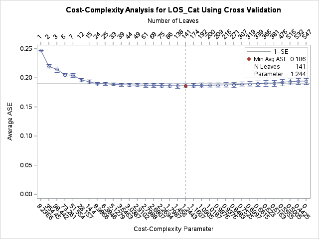

The HPSPLIT Procedure

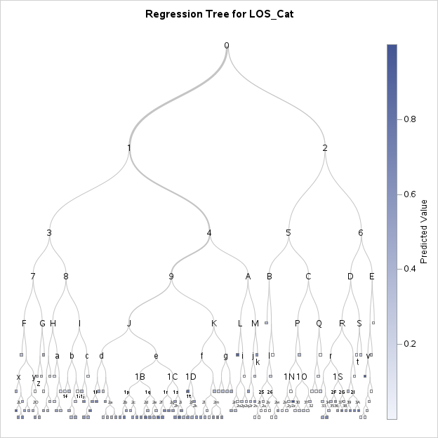

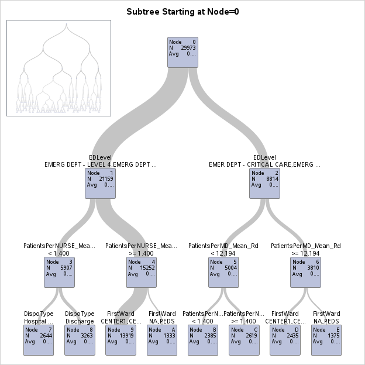

The HPSPLIT Procedure

| Model-Based Fit Statistics for Selected Tree N Leaves | Model-Based Fit Statistics for Selected Tree ASE | Model-Based Fit Statistics for Selected Tree RSS |
| --- | --- | --- |
| 151 | 0.1779 | 5333.2 |

| Variable Importance Variable | Variable Importance Training Relative | Variable Importance Training Importance | Variable Importance Count |  |
| --- | --- | --- | --- | --- |
| EDLevel | 1.0000 | 30.1164 |  | 15 |
| PatientsPerMD_Mean_Rd | 0.5739 | 17.2837 | 28 |  |
| FirstWard | 0.5267 | 15.8630 | 16 |  |
| PatientsPerNURSE_Mean_Rd | 0.4880 | 14.6961 | 13 |  |
| Arrival Shift (1st: 12 AM) | 0.3736 | 11.2511 | 12 |  |
| TransportArrive | 0.3179 | 9.5735 | 10 |  |
| DispoType | 0.3051 | 9.1881 | 11 |  |
| PatientsPerPA_RESIDENT_Mean_Rd | 0.2272 | 6.8428 | 18 |  |
| Arrival Day | 0.2110 | 6.3536 | 21 |  |
| Ward Change | 0.1132 | 3.4101 | 6 |  |

The HPSPLIT Procedure

| Performance Information |  |
| --- | --- |
| Execution Mode | Single-Machine |
| Number of Threads | 2 |

| Data Access Information Data | Data Access Information Engine | Data Access Information Role | Data Access Information Path |
| --- | --- | --- | --- |
| WORK.TEST | V9 | Input | On Client |

| Model Information |  |
| --- | --- |
| Split Criterion Used | Variance |
| Pruning Method | Cost-Complexity |
| Subtree Evaluation Criterion | Cost-Complexity |
| Number of Branches | 2 |
| Maximum Tree Depth Requested | 10 |
| Maximum Tree Depth Achieved | 10 |
| Tree Depth | 10 |
| Number of Leaves Before Pruning | 456 |
| Number of Leaves After Pruning | 33 |

| Number of Observations Read | 12848 |
| --- | --- |
| Number of Observations Used | 12848 |

The HPSPLIT Procedure

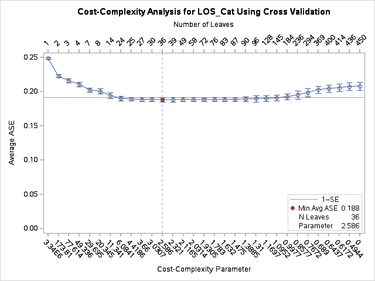

The HPSPLIT Procedure

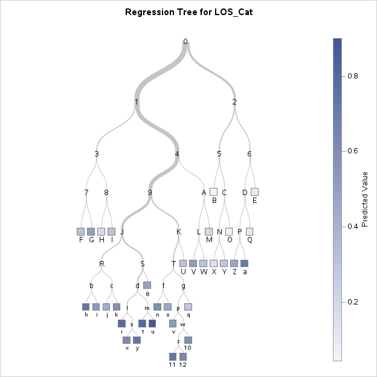

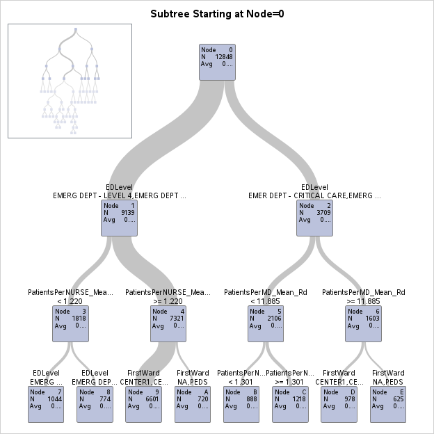

The HPSPLIT Procedure

| Model-Based Fit Statistics for Selected Tree N Leaves | Model-Based Fit Statistics for Selected Tree ASE | Model-Based Fit Statistics for Selected Tree RSS |
| --- | --- | --- |
| 33 | 0.1836 | 2359.4 |

| Variable Importance Variable | Variable Importance Training Relative | Variable Importance Training Importance | Variable Importance Count |  |
| --- | --- | --- | --- | --- |
| EDLevel | 1.0000 | 19.6873 |  | 5 |
| FirstWard | 0.5913 | 11.6415 | 5 |  |
| PatientsPerNURSE_Mean_Rd | 0.5237 | 10.3101 | 3 |  |
| PatientsPerMD_Mean_Rd | 0.5182 | 10.2020 | 7 |  |
| Arrival Shift (1st: 12 AM) | 0.3460 | 6.8114 | 4 |  |
| TransportArrive | 0.3039 | 5.9826 | 3 |  |
| DispoType | 0.1469 | 2.8912 | 2 |  |
| PatientsPerPA_RESIDENT_Mean_Rd | 0.1428 | 2.8110 | 2 |  |
| Arrival Day | 0.0649 | 1.2780 | 1 |  |

Confusion Matrix for Logistic Regression

The FREQ Procedure

| Frequency |
| --- |

| Table of LOS_Cat by Predicted_Class LOS_Cat | Table of LOS_Cat by Predicted_Class Predicted_Class No Prolonged LOS | Table of LOS_Cat by Predicted_Class Predicted_Class Prolonged LOS | Table of LOS_Cat by Predicted_Class Predicted_Class Total |
| --- | --- | --- | --- |
| No Prolonged LOS | 5008 | 1910 | 6918 |
| Prolonged LOS | 1824 | 4106 | 5930 |
| Total | 6832 | 6016 | 12848 |

Statistics for Table of LOS_Cat by Predicted_Class

| Statistic | DF | Value | Prob |
| --- | --- | --- | --- |
| Chi-Square | 1 | 2222.6438 | <.0001 |
| Likelihood Ratio Chi-Square | 1 | 2287.2605 | <.0001 |
| Continuity Adj. Chi-Square | 1 | 2220.9721 | <.0001 |
| Mantel-Haenszel Chi-Square | 1 | 2222.4708 | <.0001 |
| Phi Coefficient |  | 0.4159 |  |
| Contingency Coefficient |  | 0.3840 |  |
| Cramer's V |  | 0.4159 |  |

| Fisher's Exact Test |  |
| --- | --- |
| Cell (1,1) Frequency (F) | 5008 |
| Left-sided Pr <= F | 1.0000 |
| Right-sided Pr >= F | <.0001 |
| Table Probability (P) | <.0001 |
| Two-sided Pr <= P | <.0001 |

Sample Size = 12848

The MEANS Procedure

| Analysis Variable : LOS_Cat N | Analysis Variable : LOS_Cat Mean |
| --- | --- |
| 12848 | 0.4615504 |

ROC Curve Analysis for Logistic Regression

The LOGISTIC Procedure

| Model Information |  |
| --- | --- |
| Data Set | WORK.TEST_PREDICTED_EVAL |
| Response Variable | LOS_Cat |
| Number of Response Levels | 2 |
| Model | binary logit |
| Optimization Technique | Fisher's scoring |

| Number of Observations Read | 12848 |
| --- | --- |
| Number of Observations Used | 12848 |

| Response Profile Ordered Value | Response Profile LOS_Cat | Response Profile Total Frequency |
| --- | --- | --- |
| 1 | Prolonged LOS | 5930 |
| 2 | No Prolonged LOS | 6918 |

Probability modeled is LOS_Cat='Prolonged LOS'.

| Model Convergence Status |
| --- |
| Convergence criterion (GCONV=1E-8) satisfied. |

| Model Fit Statistics Criterion | Model Fit Statistics Intercept Only | Model Fit Statistics Intercept and Covariates |
| --- | --- | --- |
| AIC | 17737.059 | 14351.997 |
| SC | 17744.519 | 14366.919 |
| -2 Log L | 17735.059 | 14347.997 |

| Testing Global Null Hypothesis: BETA=0 Test | Testing Global Null Hypothesis: BETA=0 Chi-Square | Testing Global Null Hypothesis: BETA=0 DF | Testing Global Null Hypothesis: BETA=0 Pr > ChiSq |
| --- | --- | --- | --- |
| Likelihood Ratio | 3387.0614 | 1 | <.0001 |
| Score | 3095.7645 | 1 | <.0001 |
| Wald | 2559.8704 | 1 | <.0001 |

| Analysis of Maximum Likelihood Estimates Parameter | Analysis of Maximum Likelihood Estimates DF | Analysis of Maximum Likelihood Estimates Estimate | Analysis of Maximum Likelihood Estimates Standard Error | Analysis of Maximum Likelihood Estimates Wald Chi-Square | Analysis of Maximum Likelihood Estimates Pr > ChiSq |
| --- | --- | --- | --- | --- | --- |
| Intercept | 1 | -2.4476 | 0.0507 | 2330.6130 | <.0001 |
| Pred_Prob | 1 | 4.8447 | 0.0958 | 2559.8704 | <.0001 |

| Odds Ratio Estimates Effect | Odds Ratio Estimates Point Estimate | Odds Ratio Estimates 95% Wald Confidence Limits | Odds Ratio Estimates 95% Wald Confidence Limits |
| --- | --- | --- | --- |
| Pred_Prob | 127.060 | 105.318 | 153.290 |

| Association of Predicted Probabilities and Observed Responses |  |  |  |
| --- | --- | --- | --- |
| Percent Concordant | 78.3 | Somers' D | 0.567 |
| Percent Discordant | 21.7 | Gamma | 0.567 |
| Percent Tied | 0.0 | Tau-a | 0.282 |
| Pairs | 41023740 | c | 0.783 |

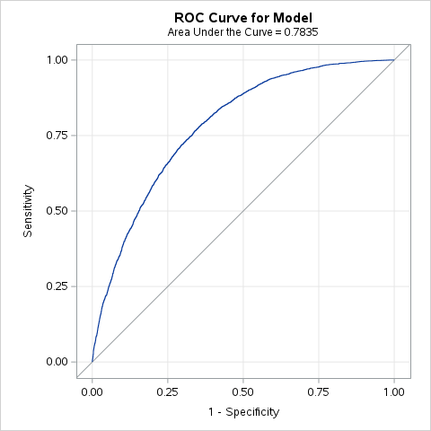

The HPSPLIT Procedure

| Performance Information |  |
| --- | --- |
| Execution Mode | Single-Machine |
| Number of Threads | 2 |

| Data Access Information Data | Data Access Information Engine | Data Access Information Role | Data Access Information Path |
| --- | --- | --- | --- |
| WORK.TEST | V9 | Input | On Client |
| WORK.TEST_XGBOOST_PRED | V9 | Output | On Client |

| Model Information |  |
| --- | --- |
| Split Criterion Used | Variance |
| Pruning Method | Cost-Complexity |
| Subtree Evaluation Criterion | Cost-Complexity |
| Number of Branches | 2 |
| Maximum Tree Depth Requested | 10 |
| Maximum Tree Depth Achieved | 10 |
| Tree Depth | 10 |
| Number of Leaves Before Pruning | 456 |
| Number of Leaves After Pruning | 33 |

| Number of Observations Read | 12848 |
| --- | --- |
| Number of Observations Used | 12848 |

The HPSPLIT Procedure

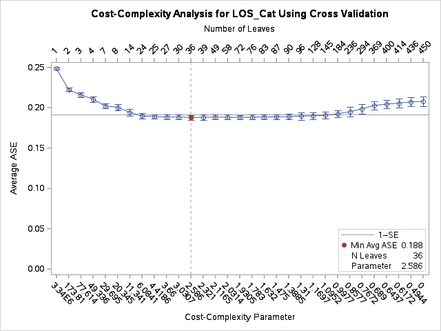

The HPSPLIT Procedure

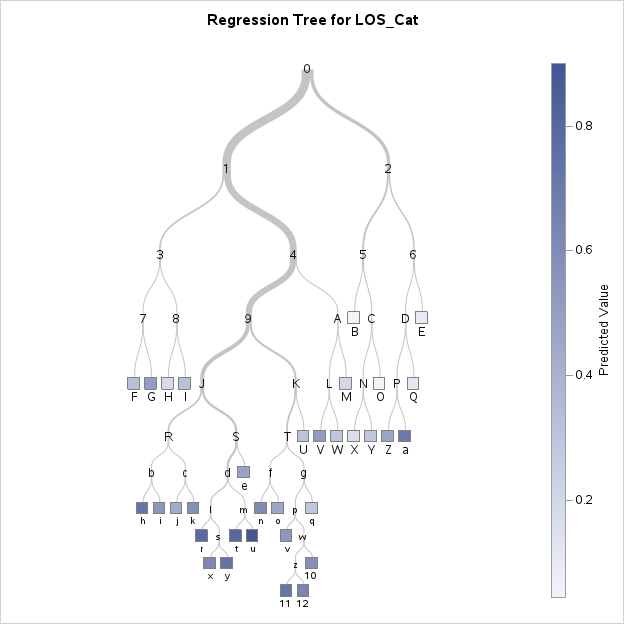

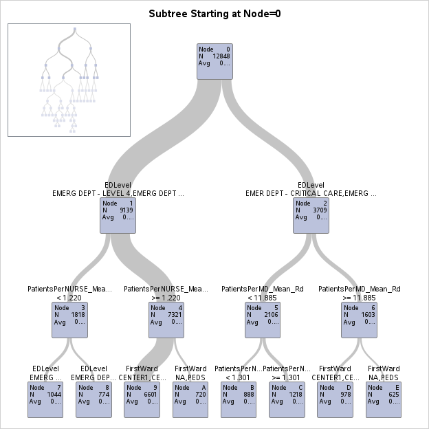

The HPSPLIT Procedure

| Model-Based Fit Statistics for Selected Tree N Leaves | Model-Based Fit Statistics for Selected Tree ASE | Model-Based Fit Statistics for Selected Tree RSS |
| --- | --- | --- |
| 33 | 0.1836 | 2359.4 |

| Variable Importance Variable | Variable Importance Training Relative | Variable Importance Training Importance | Variable Importance Count |  |
| --- | --- | --- | --- | --- |
| EDLevel | 1.0000 | 19.6873 |  | 5 |
| FirstWard | 0.5913 | 11.6415 | 5 |  |
| PatientsPerNURSE_Mean_Rd | 0.5237 | 10.3101 | 3 |  |
| PatientsPerMD_Mean_Rd | 0.5182 | 10.2020 | 7 |  |
| Arrival Shift (1st: 12 AM) | 0.3460 | 6.8114 | 4 |  |
| TransportArrive | 0.3039 | 5.9826 | 3 |  |
| DispoType | 0.1469 | 2.8912 | 2 |  |
| PatientsPerPA_RESIDENT_Mean_Rd | 0.1428 | 2.8110 | 2 |  |
| Arrival Day | 0.0649 | 1.2780 | 1 |  |

The FREQ Procedure

| Frequency |
| --- |

| Table of LOS_Cat by Predicted_Class LOS_Cat | Table of LOS_Cat by Predicted_Class Predicted_Class 0 | Table of LOS_Cat by Predicted_Class Predicted_Class Total |
| --- | --- | --- |
| 0 | 6918 | 6918 |
| 1 | 5930 | 5930 |
| Total | 12848 | 12848 |